# Systematicity over the course of early development: an analysis of phonological networks

Catherine E. Laing

1  
catherine.laing@york.ac.uk

Abstract

This paper explores the early lexicons of nine infants acquiring English or French to determine the extent of systematicity in the early vocabulary, and how this changes over time. Network graphs are generated from the point of first word production in the data set until age 30 months. Two measures of systematicity - mean path length and clustering coefficient - are analysed to establish the extent to which the early productive lexicon consists of closely-connected clusters of similar-sounding forms. Results show that early production is highly systematic when compared to random, prototypical and adult phonological networks, but that the network becomes more dispersed as it increases in size. Connectivity within the network is consistently higher for infants’ actual productions when compared with the adult target forms, and this effect increases over time. This suggests a systematic approach to production over the course of early development.

Infants’ early words are phonologically similar to one another, if not in the vocabulary items they choose to produce, but in the way they produce them. This has been well-documented in a number of previous studies (e.g. Szreder 2013; Vihman 2016; Waterson 1971), and can be clearly observed in datasets of early productions. For example, an inspection of Deuchar and Quay’s (2000) record of their Spanish-English bilingual child’s vocabulary acquisition shows that many of her earliest words are produced with an open CV syllable, and she produces a number of identical forms to refer to a range of different (though phonologically-similar) words. This suggests that infants may be drawing on a systematic approach to early productions, whereby a small subset of simple phonological forms are used to produce a range of more varied and phonologically-challenging adult targets. We would expect, therefore, that newly-acquired productions ‘cluster together’ with existing forms, with high phonological similarity between new words and existing words in the lexicon. This paper will test this by analysing network graphs of the early vocabulary to determine how similar infants’ words are to one another, and how this changes over time.

Network analysis is an increasingly popular method of analysing lexical acquisition, and offers an opportunity to consider production data on a larger scale than has previously been possible. Network models allow the analysis of connectivity within a system (in our case, the lexical or phonological system), and can track how that connectivity changes over time. In the case of language development, the nodes (individual items) in the network typically consist of words, and these are connected (or not) depending on how similar two nodes are in phonological or semantic space. Two words that are more similar to one another will be positioned closer together in the network, and less similar nodes further apart. Because this is a convenient way to think about language development over time, a number of studies have considered vocabulary acquisition within this framework. Analyses have considered infants acquiring their first language (e.g. Amatuni and Bergelson 2017; Fourtassi, Bian, and Frank 2020) and adults acquiring a novel language (e.g. Luef 2022; Mak and Twitchell 2020; Siew and Vitevitch 2020).

Systematicity is apparent across many linguistic domains, from phonology to syntax, and is noted as being pervasive in linguistic structure (Dingemanse et al. 2015; Nölle et al. 2018). It is suggested that systematicity may have evolved through transmission over generations, as linguistic structure becomes increasingly ordered through use (Kirby, Cornish, and Smith 2008). This may be a “design feature” of language that makes it easier to acquire and transmit, as has been shown for adults (Kirby, Cornish, and Smith 2008; Raviv, Heer Kloots, and Meyer 2021), children (Raviv and Arnon 2018), and in computational research (Monaghan 2011). Systematicity may be thus be important in supporting the cognitive processes required to acquire a first language. In early phonological development, systematicity is most comprehensively discussed in work by Vihman and colleagues (e.g. Vihman 2016, 2019; Vihman and Keren-Portnoy 2013; Vihman and Croft 2007). In more than four decades of work, incorporating data from a large number of infants acquiring an impressive range of languages, Vihman demonstrates a clear systematicity in infants’ path to target-like word production. From the initial ‘surprisingly accurate’ forms that appear in the first stages of word production, infants are shown to draw on what they know: they generally choose, for first production, words that are simple in their target phonological form, with consonants that are already familiar from the most common syllables of canonical babble (McCune and Vihman 2001). These forms are, in Vihman’s terms, *selected* for first word production owing to their easily-producible features. As the vocabulary grows, infant must necessarily acquire forms that do not contain such accessible phonological or segmental properties. Here we begin to see regression in the accuracy of early production, as infants systematically adapt forms to fit the most common structures and segments in their repertoire. When words are systematically altered to fit a dominant pattern in the child’s output, these forms are said to be *adapted*. Systematicity is apparent not just in the earliest words, but across the trajectory of acquisition as infants deal with the challenges of early word production by relying on well-rehearsed output forms. Over the first months of lexical development at least, infants’ productions of newly-acquired words are likely to match their productions of existing words in the lexicon.

These methods have already been used to analyse vocabulary networks across different kinds of data. Laing (2024) drew on corpus data of fortnightly word production across nine infants; Kalinowski and colleagues (in prep) take a similar approach to Laing by analysing vocabulary norms from >1000 Norwegian infants taken longitudinally at up to six individual time-points. Their results also show evidence for systematicity in the target words acquired in early acquisition (the analysis of vocabulary norms means it is not possible to observe infant productions of these words). Systematicity was also identified in early word learning by Siew and Vitevitch (2020), in an analysis of vocabulary norms of children aged 3-9 years acquiring English and Dutch. Fourtassi and colleagues (2020), on the other hand, found no support for systematicity in their analysis of infants acquiring a range of 10 different languages, instead showing that salient properties of the input, rather than previously-learned phonological properties, predicted learning.

Note that the previous studies reported above (with the exception of Laing (2024)) all draw on vocabulary norming data, meaning that infants’ actual productions (i.e. the way they produce words) is not considered. One of the key strengths of Laing (2024) and the current paper is the application of phonological network analysis to real production data. From decades of work on early phonological development, we know that infants’ earliest words are often far-removed, phonologically speaking, from their adult targets. For example Priestley’s (1977) son is reported to produce *banana* as /bajan/, *sucker* as /fajak/, *chocolate* as /kajak/ and *medicine* as /mejas/ within the same week at age 1;10. The adult target forms are all highly variable in form, while the child forms all share the systematic implementation of a disyllabic production pattern with medial /j/, following the structure CVCVC. Such systematicity cannot even be hinted at from an analysis of the target forms only, thereby losing what may be a crucial aspect of the acquisition process. Moreover, Fourtassi and colleagues (2020) and Siew and Vitevitch (2020) draw on vocabulary norming data from a cross-sectional sample of infants, meaning it is only possible to take a very general view of acquisition, with no scope for considering individual variability across the sample. This work thus cannot address any questions about systematicity in early acquisition (though note that this was not the intention of either paper).

This paper contributes a novel approach to the study of developmental vocabulary networks by analysing network *graphs*, rather than network *growth models* to study phonological networks in the developing vocabulary. All the previous work reported above uses network growth algorithms to test whether learning can be predicted based on the words that infants already know or produce. Such an approach can be used to test and/or compare different theoretical models of acquisition, whereby different network growth algorithms that index different predictions can be used as predictors in statistical models. Moreover, network growth models analyse connectivity (are two words similar, yes or no? if yes then they are connected in the network), rather than phonological distance (*how* similar are two words in the network?), and analyse the possibility of a new word being added to the network at the next time-point, rather than the static properties of a network at a given time-point. Network graphs, on the other hand, allow us to understand more about the properties of the network at a given time-point: how ordered/random the network is, how dense its clusters are, and how closely connected words are to one another across the network. Crucially, this will allow us to make predictions about network properties over time that reflect word selection and adaptation, and thus presents an opportunity to apply Vihman’s framework on a broader scale. Following Laing (2024), this paper will analyse infants’ actual productions as well as the adult target forms, to test the extent to which systematicity is present in production, in terms of both the words infants select in early development, and how they produce them.

## Research questions and predictions

1. How systematic are early word productions (both actual and target), and (how) does this change over time?
2. Are the phases of word selection and adaptation identifiable in the dataset?

To address the second question, network graphs of infants’ actual productions will be compared with those of the target form, to trace the ‘target-likeness’ of individual productions, and how this changes over time. Following Vihman once again, early word selection would be reflected in early similarities between Actual and Target network properties, as target forms are selected to match the structures and segments that infants are able to produce, meaning they should be produced with relative accuracy. Over time, Actual and Target forms are expected to diverge, such that Actual forms show more systematicity in the data than Target forms. Approaches used to test these predictions are outlined in detail below.

# Methods

## Data extraction and preparation

This study draws on the same data as that analysed by Laing (2024). This was drawn from two corpora on PhonBank (Rose and MacWhinney 2014): Providence (American English - Demuth, Culbertson, and Alter 2006) and Lyon (French - Demuth and Tremblay 2008). These were selected due to their equivalent data collection methods and the fact that the infants’ productions, as well as the corresponding target forms, are phonetically transcribed. Nine infants’ (5 English, 4 French, 4 boys overall) data were extracted using Phon (Hedlund and Rose 2020), from the transcript with their first-recorded word to the final transcript taken at age 2;6. Infants were recorded in the home on a fortnightly basis, participating in naturalistic interactions with their caregivers. Two of the American infants were recorded weekly during some periods of data collection, but this is not an issue for this analysis since no between-child comparisons will be made. See Demuth et al. (2006) and Demuth and Tremblay (2008) for full details of data collection.

```r
types.corpus <- comparison_data %>%
  group_by(corpus, Speaker) %>%
  distinct(Gloss, .keep_all=T) %>%
  tally() %>% summarise(n=sum(n))

types <- comparison_data %>%
  group_by(Speaker) %>%
  distinct(Gloss, .keep_all=T) %>%
  tally() %>% summarise(n=sum(n))

tokens <- comparison_data %>%
  group_by(Gloss, Speaker, Session) %>%
  tally() %>% ungroup() %>%
  summarise(mean_tok=mean(n),
            sd_tok=sd(n))

tokens.corpus <- comparison_data %>%
  group_by(Gloss, Speaker, Session, corpus) %>%
  tally() %>% ungroup() %>%
  group_by(corpus) %>%
  summarise(mean_tok=mean(n),
            sd_tok=sd(n))
```

Extracted data was filtered to include only words featuring on the communicative development inventory (CDI) of the respective language, including all variants of a given form (including a total of 680 possible word types for American English and 690 for European French). For example, plurals were included alongside the singular noun form, and variable verb conjugations alongside their corresponding infinitive verb form. There were 5483 non-CDI words in the initial dataset, all of which were excluded from the analysis (by language: 2224 in French and 3259 in English). The final dataset includes 3320 word types overall, aggregated across infants (English= 2024, French=1296).

Distance scores were generated between each word and each other word in each child’s dataset, for both Target and Actual forms. These scores were then normalised, and a normalised distance of 0.25 was chosen to indicate connectivity. That is, words were said to be connected in the network if their distance score was 0.25 or less. This accounted for the lower quartile of connectivity across the dataset. For a full overview of the data preparation process, including validation of the 0.25 connectivity threshold, see Laing (2024, supplemental materials).

The final dataset includes 3320 word types in total, with 2024 in the English corpus and 1296 in the French corpus. On average, infants produced 8 tokens of each word type in a single session (SD = 18; mean English tokens = 6, SD = 11; mean French tokens = 13, SD = 29).

## Data analysis

### Network graphs

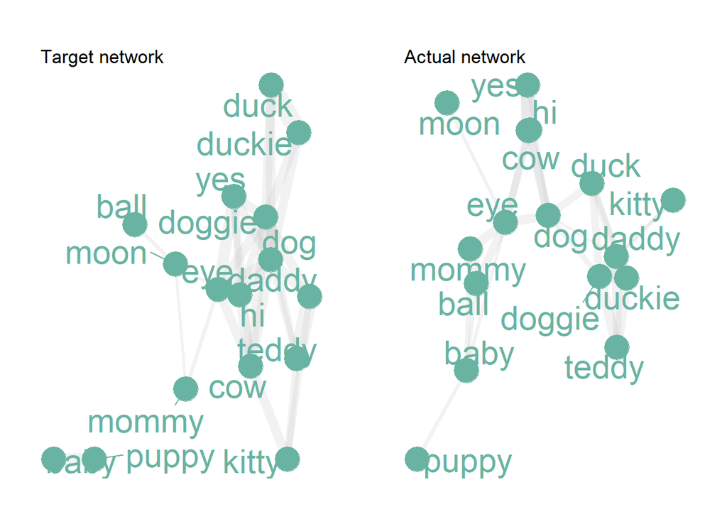

Two networks generated from one English-acquiring infant’s data. The networks incorporate all words produced by the child upto and including age 14 months. The Target network is shown on the left, and the Actual network on the right. Teal dots represent nodes (words) in the network, and lines between the dots are the edges. Thicker lines represent shorter phonological distances (these are also visually represented in graph space, whereby closer phonological distance is represented by nodes plotted more closely together). Words represent the target words, though note that the Actual network plots distance between words as produced by the infant. Hermit words had a scaled distance of >.25 to all other words in the network.

Two key variables will be explored through an analysis of network graphs: *mean path length* and *average clustering coefficient*. These have been calculated from a measure I refer to here as phonological distance, which is derived from the Euclidean distance between pairs of consonants across any given two words in the dataset. Path length is a measure of distance between nodes, and mean path length indexes the average phonological distance (of all connected nodes) within a network; by this measure, we would expect that systematicity in early phonological development would be reflected in *low* mean path length, as words are, on average, more closely connected. Clustering coefficient is an indication of network density: a *higher* average density of nodes in the network indicates denser clusters of similar forms; again, this is what we would expect to see in a network of early phonological development. See Goldbeck (2013) for a full overview of network structures and measures.

### Simulated networks

Networks with high phonological systematicity should exhibit properties of prototypical “small-world” network growth, namely a low mean path length and a high average clustering coefficient (Watts and Strogatz 1998; Amaral et al. 2011; Steyvers and Tenenbaum 2005). Words should be more densely connected, with shorter connections between words. As this is what we expect to see in the phonological networks tested here, small-world networks serve as a suitable comparison with the real data. If high systematicity is present in the data, then there should be no statistical difference between the real network and a small-world network of equal size. To test this, mean path length and clustering coefficient values were generated for both the Target and Actual networks, as described above. Data were then compared to the growth of a simulated small-world network of equal size, known as a Watts-Strogatz network (Watts and Strogatz 1998). This network was generated computationally in R using the *igraph()* package (Csardi and Nepusz 2006), and was matched for network size and mean connectivity within the network at each month. The real data were also compared to a similarly-sized but randomly-generated network known as a Erdős–Rényi model. If the real network grows in a systematic way, then we would expect the real data to differ significantly from the randomly-generated Erdős–Rényi network. Again, this was generated using the *igraph()* package (Csardi and Nepusz 2006), and was matched for network size at each month (but not mean connectivity, as this is not required for a random graph). To run these analyses, mean path length and clustering coefficient were calculated for each monthly graph - the Real data, and the two kinds of simulated data (prototypical systematic network vs. random network) - and the two kinds of Simulated network were tested against the Real network.

### Statistical models

Two different analysis methods will be drawn upon to test the two research questions. To test RQ1, network graphs will be compared to simulated small world and random networks of equivalent size to determine whether the data (the *Real* network, drawing from infants’ Actual productions) differs from the *Simulated* networks using linear mixed effects regression models. To test RQ2, generalised additive mixed effects models (GAMMs) will be used, since these allow the analysis of non-linear change over time, and can account for statistical differences between two non-linear trajectories of data that may differ in non-linear ways (Sóskuthy 2017; Wieling 2018). Fixed effects in the model can include parametric terms, as is typical in regression modelling, and also *smooth terms*, or non-linear fixed effects. Much like mixed-effects linear models, GAMMs can account for random effects in the data; in this case by-subject random effects were included through the addition of *random smooths* in the model.

To account for the fact that adjacent values (i.e. connectivity at month *n* and month *n+1*) are likely correlated, GAMM modelling includes an autocorrelation parameter; see Sóskuthy (2017) and Wieling (2018) for full details. Additionally, the start point for each infant’s data (i.e. their first recording session) was indexed in the model.

# Results

## RQ1: How systematic are early word productions, and (how) does this change over time?

For both mean path length and clustering coefficient, we would expect the Real data to differ significantly from the Simulated Erdős–Rényi (random) network, and for the Real network to show similar properties to the Simulated Watts-Strogatz (small-world) network. Note that the extent of the expected statistical difference is not easy to predict here: if the Real network is very similar to the Watts-Strogatz network then no statistical difference would be expected, but this relies on the Real data being highly systematic, which may not be realistic. In order to fully understand the nature of the data, figures and model outputs will be inspected in relation to these predictions.

### Mean Path Length

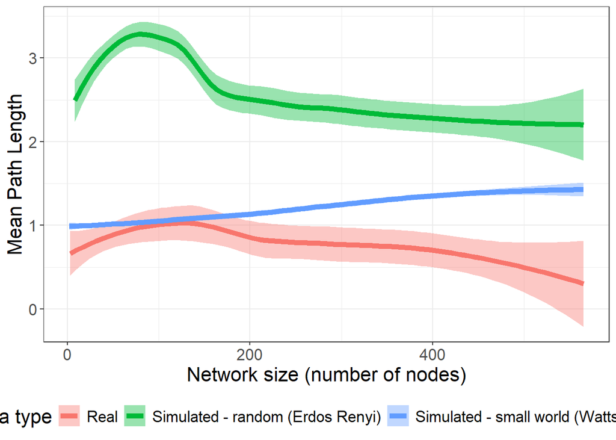

Change in mean path length as network size increases, in Real vs. Simulated (random and small-world) data. Coloured lines represent Data type; coloured bands represent 95% CIs. See S2 for the same data plotted according to the effect of Age.

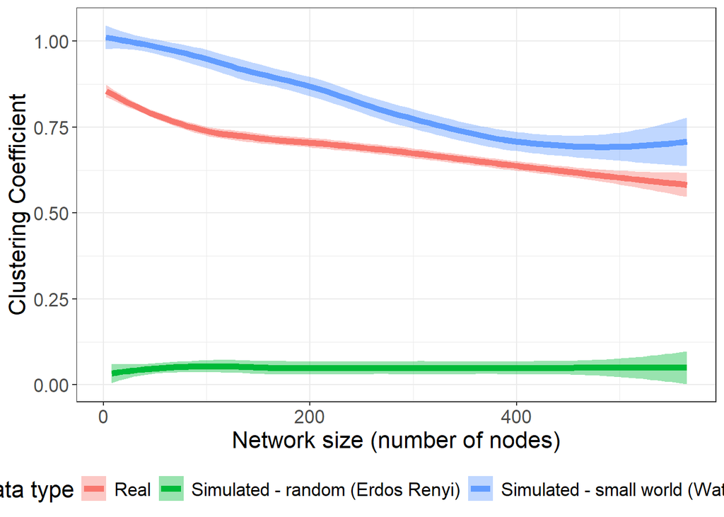

Change in clustering coefficient as network size increases, in Real vs. Simulated (random and small-world) data. Coloured lines represent Data type; coloured bands represent 95% CIs. See S2 for the same data plotted according to the effect of Age.

### Actual vs. Target data

The differences between the Real data and the small-world Simulated data are difficult to interpret, given that there is no clear model of what phonological systematicity would look like in a highly systematic small-world network. To further interrogate systematicity within the data, network properties of the Real (Actual) data analysed above were compared to the Real Target data - that is, the phonological distance (taken from the IPA transcriptions) between the child’s Actual production and its Target counterpart was analysed. Target data serves as an appropriate proxy for connectivity and clustering within a “standard” phonological network, albeit a network that is constrained by words produced in early acquisition, and further constrained by the fact that only a subset of these (i.e. CDI words) are included in the data set. We would expect that mean path length and clustering coefficient would each show higher systematicity in the Actual network than the Target network[^2]. Basic model structure was the same as reported above, but with only Real data (Actual vs. Target) considered as a fixed effect. The inclusion of Network size as a fixed effect improved model fit for both dependent variables and so was included in both models.

```r
SWD_red$start.event <- SWD_red$session_ordinal == 1

globalthresholds$start.event <- globalthresholds$threshold == 0.01

# create dummy variable for actual vs. target

globalthresholds$IsActual <- (globalthresholds$data_type == "actual")*1
```

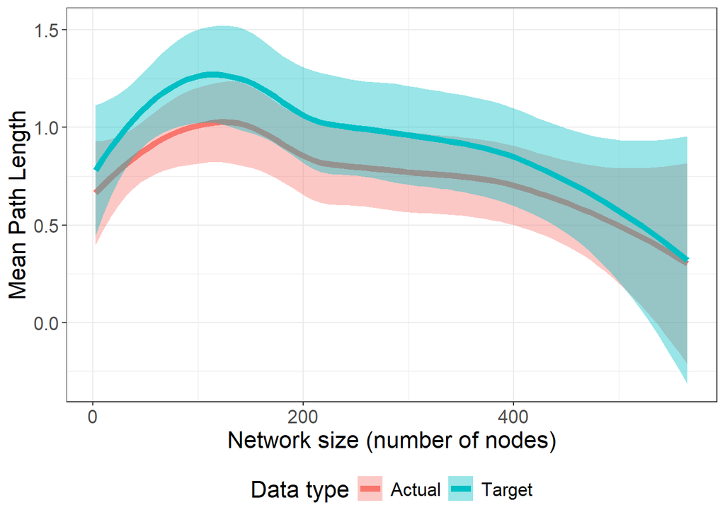

Change in mean path length as network size increases, in Actual vs. Target data. Coloured lines represent Data type; coloured bands represent 95% CIs. See S2 for the same data plotted according to the effect of Age.

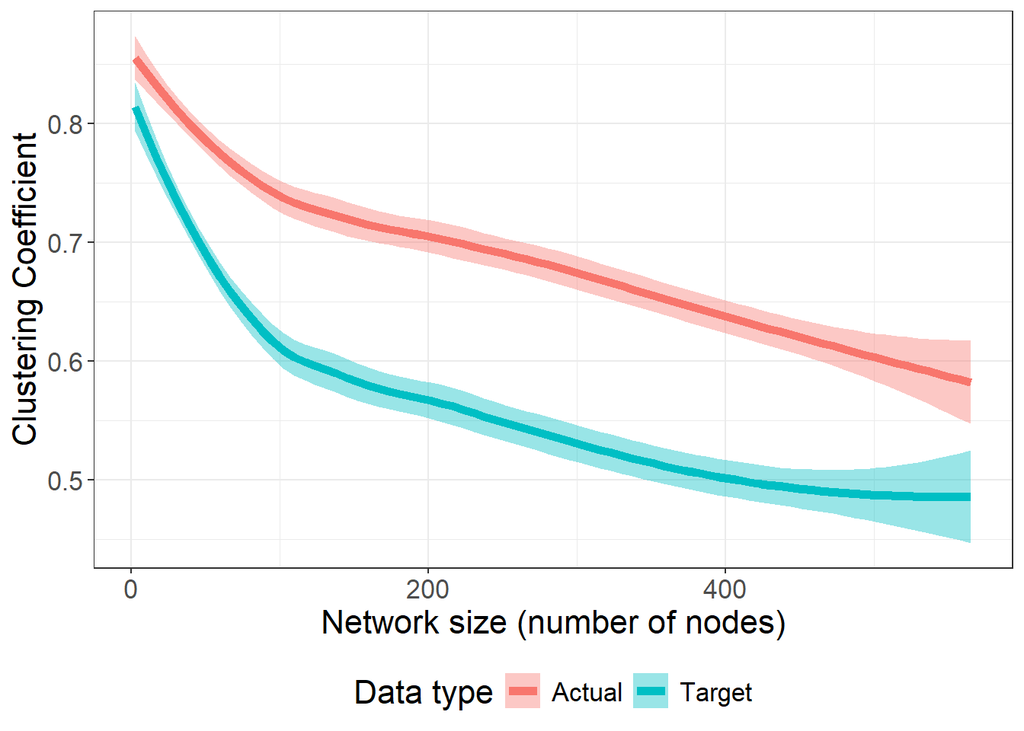

Change in mean clustering coefficient as network size increases, in Actual vs. Target data. Coloured lines represent Data type; coloured bands represent 95% CIs. See S2 for the same data plotted according to the effect of Age.

## RQ2. Is there evidence of word selection and adaptation in the dataset?

To address the second research question, the phonological distance between Target and Actual forms was taken as a proxy of word selection and adaptation. That is, if a word is produced in a target-like way (i.e. assumed to be selected[^3]), then the phonological distance between the Target form and the way it is produced (Actual form) should be low. The opposite is true for adapted forms, as we expect, by definition, a non-target-like production and thus a higher distance between Target and Actual form. This measure is not perfect, but coding selected/adapted forms would otherwise have to be done by hand, which is not feasible across such a large dataset. Following Vihman’s (2019) framework, we would expect low distance between Actual and Target forms earlier on in development as words are selected, and higher distance later as word adaptation begins to take hold.

GAMMs were used to examine connectivity of the infants’ Actual and Target networks and how these changed over time. These were run using the *mgcv()* package in R (Wood 2011). These models analyse the extent to which the two networks differ (or not) from one another across infants, and how this changes non-linearly month-by-month. The model tested mean number of connections in the network (average number of connections of each node in the network, or mean *k*) as the dependent variable, working on the assumption that connectivity in the Target vs. Actual networks would be similar during periods of word selection (i.e. Actual and Target words are similar to one another and so distribution of connectivity should be similar), and would differ during periods of adaptation. Specifically, periods of adaptation should lead to higher connectivity in the Actual network than the Target network, since we expect productions to be more similar (and thus more well-connected) in Actual forms; we would expect connectivity across data types to diverge at the point that word adaptation begins to take hold. A higher number of connections (higher mean *k*) for Actual vs. Target networks is expected during periods of adaptation, and no difference in connectivity is expected for periods of selection. Data type (Actual vs. Target) and Corpus (English vs. French) were included as parametric terms, with Data type being the variable of interest in the model. Network size and Age were included as smooth terms, as well as by-Subject and by-Data type random smooths for the effect of Age, which account for by-Subject and by-Data type differences in the data over time. To test for an effect of Data type, model comparisons were run using the *compareML()* function from the *itsadug()* package (Rij et al. 2022): the full model including the effect of Data type and the by-Data type random smooth was compared to a model without these terms. Because model summaries for GAMM smooths may be non-conservative (Sóskuthy 2017), smooth plots will be observed alongside any significant effects to determine relevant trends in the data.

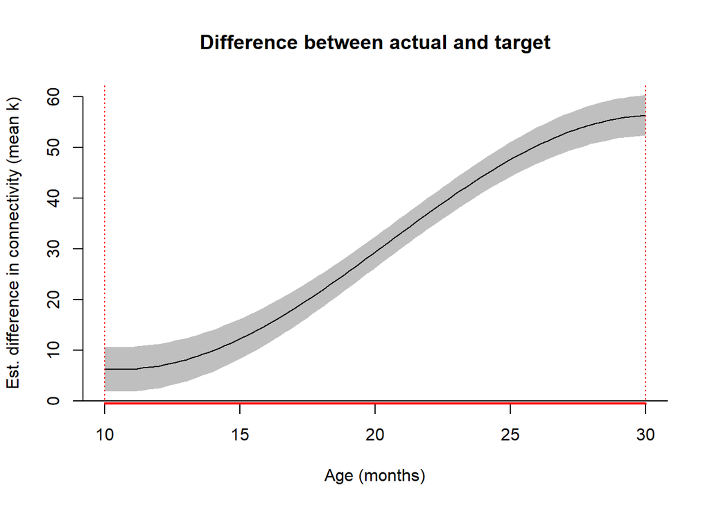

Difference smooth plot showing difference between connectivity (mean k) in Actual vs. Target forms from the GAMM model specified above. Shaded area shows 95% confidence intervals, red line along x-axis indicates months in which the difference between Actual and Target forms was significant.

# Discussion

This paper set out to test the presence of systematicity in infants’ developing lexicons by analysing phonological network graphs from nine infants acquiring French or English. Network graphs allow a close-up view of phonological similarity between forms within the network (via mean path length) and the extent to which groups of phonologically similar forms cluster together (via average clustering coefficient). Systematicity in the network would be reflected in shorter distance between forms and higher clusters of phonologically similar forms. The analysis also sought to identify periods of selection and, later, adaption - indicating a shift towards increasing systematization - in the data.

The second research question attempted to identify periods of word selection and adaption in the data using generalised additive mixed models (GAMMs). This analysis worked on the assumption that overall connectivity in the network (mean number of connections per node, or mean *k*) should be similar for Actual and Target forms during periods of word selection, since infant productions should be more phonologically accurate for selected words, and thus similar in connectivity to the target forms. Periods of adaptation, on the other hand, should see a difference in connectivity between Target and Actual data; new Target forms in the network will be more distant, and less likely to connect to existing forms, whereas Actual forms should continue to connect to existing words in the network. Thus, we expect a divergence between connectivity in the Target and Actual networks. This was, to some extent, borne out in the data, though distinct periods of selection and adaptation could not be identified. Instead, a gradual increase in the difference in connectivity between Actual and Target networks was observed over time; the difference in connectivity was always significant, and mean *k* was always higher in Actual than Target networks.

One key question arising from these findings is the extent to which network graphs - in particular the measures used in this study - can help us understand systematicity. Even though this analysis incorporated a more close-up analysis of network properties than those that draw on network growth models alone - i.e., by taking into account distribution of the nodes within the networks across three measures (mean path length, average clustering coefficient, and mean *k*) - still the analyses all abstract away from the detail of early word production, and specifically what drives connectivity and clustering within the network. The measures used to generate phonological distance were not able to take into account holistic or prosodic properties of early words, so we lose a potential source of connectivity within the networks (for example, a reliance on consonant harmony, which reveals within-word, as well as potential between-word, systematicity). Kalinowski and colleagues (in prep) take steps towards addressing this in their analysis, showing the potential for even more nuanced indices of phonological distance by iterating across, as well as between, similarities within words in the network. Moreover, infants are likely to have drawn on different approaches to early word production, some which might have been represented as systematic more effectively by the measures used here. Finally, the focus on mean *k* to analyse word selection and adaptation is a crude measure for identifying changes in the data that are likely very subtle. Future work may want to draw on cluster analysis to observe these changes in the data more closely. That being said, phonological distance between Target and Actual forms may be a useful measure for objectively identifying word selection or adaptation in future studies.

While this analysis presents a more nuanced view of systematicity than in previous studies that draw entirely on network growth models, including Laing (2024), Fourtassi and colleagues (2020) and Siew and Vitevitch (2020), closer inspection of the network graphs themselves may have been useful in supporting and explaining the findings in more detail. Future work could combine computational analyses of networks with a more impressionistic analysis of infants’ early word productions to bring together these two very different but equally valuable methodologies. Indeed, drawing on modelling to understand large-scale data makes it possible to quantify findings in a more rigorous way, but it abstracts away for the nature of early productions and means we miss out on the detail of the patterns that are being drawn upon. It also overlooks the extent to which infants take very individualised paths in phonological development (Vihman 1993), and the possibility that broad-scale generalization is simply not reflective of the reality of early production. Future studies in this area may want to consider how variability between infants, and infants acquiring different languages, is represented in vocabulary growth networks.

# References

```r
r_refs(file="r-references.bib")
```

Amaral, L. A. N., A. Scala, M. Barthelemy, and H. E. Stanley. 2011. “Classes of Small-World Networks.” In *The Structure and Dynamics of Networks*, 207–10. Princeton, NJ: Princeton University Press.

Amatuni, Andrei, and Elika Bergelson. 2017. “Semantic Networks Generated from Early Linguistic Input.” Preprint. https://doi.org/10.1101/157701.

Csardi, Gabor, and Tamas Nepusz. 2006. “The Igraph Software Package for Complex Network Research.” *InterJournal* Complex Systems: 1695. https://igraph.org.

Demuth, Katherine, Jennifer Culbertson, and Jennifer Alter. 2006. “Word-Minimality, Epenthesis and Coda Licensing in the Early Acquisition of English.” *Language and Speech* 49 (2): 137–74.

Demuth, Katherine, and Annie Tremblay. 2008. “Prosodically-Conditioned Variability in Children’s Production of French Determiners.” *Journal of Child Language* 35 (1).

Deuchar, M., and S. Quay. 2000. *Bilingual Acquisition: Theoretical Implications of a Case Study*. Oxford, UK: Oxford University Press.

Dingemanse, Mark, Damián E. Blasi, Gary Lupyan, Morten H. Christiansen, and Padraic Monaghan. 2015. “Arbitrariness, Iconicity, and Systematicity in Language.” *Trends in Cognitive Sciences* 19 (10): 603–15. https://doi.org/10.1016/j.tics.2015.07.013.

Donegan, Patricia. 2013. “Normal Vowel Development.” In *Handbook of Vowels and Vowel Disorders*, edited by M. J. Ball and F. E. Gibbons, 24–60. Psychology Press.

Fourtassi, Abdellah, Yuan Bian, and Michael C. Frank. 2020. “The Growth of Children’s Semantic and Phonological Networks: Insight from 10 Languages.” *Cognitive Science* 44 (7): e12847. https://doi.org/10.1111/cogs.12847.

Golbeck, Jennifer. 2013. *Analyzing the Social Web*. San Francisco, UNITED STATES: Elsevier Science & Technology.

Hedlund, Gregory, and Yvan Rose. 2020. “Phon 3.1 [Computer Software].” https://phon.ca.

Kalinowski, Judith, Laura Hansel, Michaela Vystrčilová, Alexander Ecker, and Nivedita Mani. in prep. “The Development of Early Phonological Networks: An Analysis of Individual Longitudinal Vocabulary Growth,” in prep.

Kent, Ray D., and Carrie Rountrey. 2020. “What Acoustic Studies Tell Us about Vowels in Developing and Disordered Speech.” *American Journal of Speech-Language Pathology* 29 (3): 1749–78. https://doi.org/10.1044/2020_AJSLP-19-00178.

Kirby, Simon, Hannah Cornish, and Kenny Smith. 2008. “Cumulative Cultural Evolution in the Laboratory: An Experimental Approach to the Origins of Structure in Human Language.” *Proceedings of the National Academy of Sciences* 105 (31): 10681–86. https://doi.org/10.1073/pnas.0707835105.

Laing, Catherine E. 2024. “Phonological Networks and Systematicity in Early Lexical Acquisition.” *Journal of Experimental Psychology: Learning, Memory, and Cognition*. https://doi.org/https://doi.org/10.1037/xlm0001368.

Luef, Eva Maria. 2022. “Growth Algorithms in the Phonological Networks of Second Language Learners: A Replication of Siew and Vitevitch (2020a).” *Journal of Experimental Psychology: General* 151 (12): e26–44. https://doi.org/10.1037/xge0001248.

Mak, Matthew H. C., and Hope Twitchell. 2020. “Evidence for Preferential Attachment: Words That Are More Well Connected in Semantic Networks Are Better at Acquiring New Links in Paired-Associate Learning.” *Psychonomic Bulletin & Review* 27 (5): 1059–69. https://doi.org/10.3758/s13423-020-01773-0.

McCune, Lorraine, and Marilyn M. Vihman. 2001. “Early Phonetic and Lexical Development.” *Journal of Speech, Language, and Hearing Research* 44 (3): 670–84. https://doi.org/10.1044/1092-4388(2001/054).

Monaghan, Padraic. 2011. “Design Features of Language Emerge from General-Purpose Learning Mechanisms.” *Proceedings of the Annual Meeting of the Cognitive Science Society* 33: 2661–66. https://doi.org/https://escholarship.org/uc/item/7q1736rb.

Monaghan, Padraic, Morten H. Christiansen, Thomas A. Farmer, and Stanka A. Fitneva. 2010. “Measures of Phonological Typicality.” *The Mental Lexicon* 5 (3): 281–99. https://doi.org/10.1075/ml.5.3.02mon.

Nölle, Jonas, Marlene Staib, Riccardo Fusaroli, and Kristian Tylén. 2018. “The Emergence of Systematicity: How Environmental and Communicative Factors Shape a Novel Communication System.” *Cognition* 181 (December): 93–104. https://doi.org/10.1016/j.cognition.2018.08.014.

Priestly, T. M. S. 1977. “One Idiosyncratic Strategy in the Aquisition of Phonology.” *Journal of Child Language* 4: 45–65.

R Core Team. 2020. *R: A Language and Environment for Statistical Computing*. Vienna, Austria: R Foundation for Statistical Computing. https://www.R-project.org/.

Raviv, Limor, and Inbal Arnon. 2018. “Systematicity, but Not Compositionality: Examining the Emergence of Linguistic Structure in Children and Adults Using Iterated Learning.” *Cognition* 181 (December): 160–73. https://doi.org/10.1016/j.cognition.2018.08.011.

Raviv, Limor, Marianne de Heer Kloots, and Antje Meyer. 2021. “What Makes a Language Easy to Learn? A Preregistered Study on How Systematic Structure and Community Size Affect Language Learnability.” *Cognition* 210 (May): 104620. https://doi.org/10.1016/j.cognition.2021.104620.

Rij, Jacolien van, Martijn Wieling, R. Harald Baayen, and Hedderik van Rijn. 2022. “itsadug: Interpreting Time Series and Autocorrelated Data Using GAMMs.”

Rose, Yvan, and Brian MacWhinney. 2014. “The PhonBank Project: Data and Software-Assisted Methods for the Study of Phonology and Phonological Development.” In *The Oxford Handbook of Corpus Phonology*, edited by J Durand, U Gut, and G Kristoffersen, 380–401. Oxford, UK: Oxford University Press.

Siew, Cynthia S. Q., and Michael S. Vitevitch. 2020. “An Investigation of Network Growth Principles in the Phonological Language Network.” *Journal of Experimental Psychology: General*, June. https://doi.org/10.1037/xge0000876.

Sóskuthy, Márton. 2017. “Generalised Additive Mixed Models for Dynamic Analysis in Linguistics: A Practical Introduction.” arXiv. http://arxiv.org/abs/1703.05339.

Steyvers, Mark, and Joshua B. Tenenbaum. 2005. “The Large-Scale Structure of Semantic Networks: Statistical Analyses and a Model of Semantic Growth.” *Cognitive Science* 29 (1): 41–78. https://doi.org/10.1207/s15516709cog2901_3.

Szreder, Marta. 2013. “The Acquisition of Consonant Clusters in Polish: A Case Study.” In *The Emergence of Phonology: Whole-Word Approaches and Cross-Linguistic Evidence*, edited by Marilyn M. Vihman and Tamar Keren-Portnoy, 343–61. Cambridge: Cambridge University Press. https://doi.org/10.1017/CBO9780511980503.016.

Vihman, Marilyn M. 1993. “Variable Paths to Early Word Production.” *Journal of Phonetics* 21: 61–82.

———. 2016. “Prosodic Structures and Templates in Bilingual Phonological Development.” *Bilingualism: Language and Cognition* 19 (1): 69–88. https://doi.org/10.1017/S1366728914000790.

———. 2019. *Phonological Templates in Development*. Oxford, UK: Oxford University Press.

Vihman, Marilyn M., and William Croft. 2007. “Phonological Development: Toward a ‘Radical’ Templatic Phonology.” *Linguistics* 45 (4). https://doi.org/10.1515/LING.2007.021.

Vihman, Marilyn M., and Tamar Keren-Portnoy. 2013. “The Emergence of Phonology: Whole-Word Approaches, Cross-Linguistic Evidence.” In *The Emergence of Phonology: Whole-Word Approaches and Cross-Linguistic Evidence*, edited by Marilyn M. Vihman and Tamar Keren-Portnoy. Cambridge: Cambridge University Press. https://doi.org/10.1017/CBO9780511980503.002.

Waterson, Natalie. 1971. “Child Phonology : A Prosodic View.” *Journal of Linguistics* 7 (2): 179–211. https://doi.org/10.1017/S0022226700002917.

Watts, Duncan J, and Steven H Strogatz. 1998. “Collective Dynamics of ‘Small-World’ Networks” 393: 3.

Wieling, Martijn. 2018. “Analyzing Dynamic Phonetic Data Using Generalized Additive Mixed Modeling: A Tutorial Focusing on Articulatory Differences Between L1 and L2 Speakers of English.” *Journal of Phonetics* 70 (September): 86–116. https://doi.org/10.1016/j.wocn.2018.03.002.

Wood, S. N. 2011. “Fast Stable Restricted Maximum Likelihood and Marginal Likelihood Estimation of Semiparametric Generalized Linear Models.” *Journal of the Royal Statistical Society (B)* 73 (1): 3–36.

[^1]: Recall that any two nodes that have a scaled phonological distance of >.25 will not be connected.
[^2]: Note that this result was observed for network growth models in Laing (2024), whereby the Actual network was found to be a better predictor of learning based on the known network of each child.
[^3]: though note that, while a selected form is, by definition, target-like in phonological form, a target-like form isn’t necessarily a selected form.